# Data Issues: Missing GCS, AIS and ISS Scores

jaegerl

2025-03-17

## Identify Cases without GCS

Check if the cases in `Pivot table nur Eingeschlossene` are the ones without a recorded GCS.

```r
# function for data import from .csv files
import_dataset <- function(...) {
  import_list(..., rbind = TRUE, setclass = "data.table")
}
# load cases
diagnoses <- suppressWarnings(import_list(paste0(import_path, "Diagnosen.xlsx"),
                                          setclass = "data.table",
                                          guess_max = 50000))
# get the relevant sheets
all_cases <- diagnoses[[2]]
included_cases <- diagnoses[[3]]
colnames(all_cases)[1] <- "research_case_id"
colnames(included_cases)[1] <- "research_case_id"

# load vitals
load(paste0(clean_path, "vitals_clean.RData"))

# get gcs values into the cases datasets
all_cases <- merge(all_cases, y = vitals_clean[, .(research_case_id,
                                                   gcs)],
                   by = "research_case_id",
                   all.x = TRUE)
included_cases <- merge(included_cases, y = vitals_clean[, .(research_case_id,
                                                             gcs)],
                        by = "research_case_id",
                        all.x = TRUE)
# identify cases without gcs
all_cases[, nogcs := as.integer(is.na(gcs))]
included_cases[, nogcs := as.integer(is.na(gcs))]
all_cases[, included := as.integer(research_case_id %in%
                                     included_cases$research_case_id)]

# look at percentages of missing GCS cases in the two cases datasets
round(xtabs(~ included + nogcs, data = all_cases) * 100 / nrow(all_cases),
      digits = 1)
```

```
##         nogcs
## included    0    1
##        0  9.2 54.5
##        1 34.1  2.2
```

```r
# among the included patients, only a very small percentage has no recorded GCS entry.
# it could be that these are cases where the GCS was present in the raw data, but not
# readable. let's check
vitals_raw <- import_dataset(paste0(import_path,
                                    "[SDS].[v_Export_Vital_Werte_tra_sds].csv"))
gcs_raw <- vitals_raw[Messung_Name == "GCS", .(research_case_id)] |>
  unique()
sum(!(included_cases$research_case_id %in% gcs_raw$research_case_id))
```

```
## [1] 427
```

## Check Diagnoses

```r
load(paste0(clean_path, "Diagnosis_cleaned.RData"))
setDT(Diagnosis_cleaned)
colnames(Diagnosis_cleaned)
```

```
##  [1] "research_case_id"
##  [2] "date"
##  [3] "bleeding"
##  [4] "fracture"
##  [5] "subdural_bleeding"
##  [6] "epidural_bleeding"
##  [7] "subarachnoid_bleeding"
##  [8] "contusion"
##  [9] "diffuse_brain_injuries_and_ripping_shearing"
## [10] "other_bleeding"
## [11] "skull_base_fracture"
## [12] "skull_cap_fracture"
## [13] "unconsciousness"
## [14] "concussion"
## [15] "brain_edema"
## [16] "brain_compression"
## [17] "concussion_correction_formula"
## [18] "concussion_correction_including_unconsciousness_in_tbi"
## [19] "injury_descriptions"
## [20] "num_injuries"
```

```r
Diagnosis_cleaned[, included := as.integer(research_case_id %in%
                                             included_cases$research_case_id)]

# inspect a few injuries
injuries <- Diagnosis_cleaned[, .(injury_descriptions)] |>
  unique()
injuries[order(str_length(injury_descriptions))] |>
  head(20)
```

```
##     injury_descriptions
##                  <char>
##  1:             dyspnoe
##  2:          hirnzysten
##  3:         analabszess
##  4:         osteoporose
##  5:        kreuzschmerz
##  6:        vergiftungen
##  7:      harnverhaltung
##  8:      akuter schmerz
##  9:      zyste der milz
## 10:     lumboischialgie
## 11:   bursitis olecrani
## 12:   unguis incarnatus
## 13:   trichilemmalzyste
## 14:   tätlicher angriff
## 15:   epidurale blutung
## 16:  meniskusriss, akut
## 17:  phlegmone an zehen
## 18: erysipel [wundrose]
## 19: fraktur der patella
## 20: prellung des thorax
##     injury_descriptions
```

```r
# for some reason, there are patients with internal, non-traumatic diagnoses.
# let's check if this is also the case among the included patients:
injuries_included <- Diagnosis_cleaned[research_case_id %in%
                                         included_cases$research_case_id,
                                       .(injury_descriptions)] |>
  unique()
injuries_included[order(str_length(injury_descriptions))] |>
  head(20)
```

```
##                                             injury_descriptions
##                                                          <char>
##  1:                                           epidurale blutung
##  2:                                         gehirnerschütterung
##  3:                        traumatische subarachnoidale blutung
##  4:                       schädeldachfraktur, epidurale blutung
##  5:                      gehirnerschütterung, tätlicher angriff
##  6:                  gehirnerschütterung, transportmittelunfall
##  7:               gehirnerschütterung, unfall sonstiger und ona
##  8:              gehirnerschütterung, transportmittelunfall ona
##  9:              intrazerebrale blutung, nicht näher bezeichnet
## 10:           umschriebene hirnkontusion, transportmittelunfall
## 11:           intrakranielle verletzung, nicht näher bezeichnet
## 12:         zahnfraktur, gehirnerschütterung, tätlicher angriff
## 13:        zahnluxation, gehirnerschütterung, tätlicher angriff
## 14:     zahnfraktur, gehirnerschütterung, transportmittelunfall
## 15:     umschriebenes zerebrales hämatom, transportmittelunfall
## 16:    nasenbeinfraktur, gehirnerschütterung, tätlicher angriff
## 17:    schädeldachfraktur, epidurale blutung, tätlicher angriff
## 18:   hypothyreose, nicht näher bezeichnet, schädelbasisfraktur
## 19: offene wunde: lippe, gehirnerschütterung, tätlicher angriff
## 20: gehirnerschütterung, prellung des thorax, tätlicher angriff
##                                             injury_descriptions
```

```r
# ok, the simplest cases seem to have at least one head injury. however, it is
# not clear to me why they would be classified as polytrauma cases?

# let's do a deeper check with the raw diagnoses dataset
diagnoses_raw <- diagnoses[[1]]
colnames(diagnoses_raw)
```

```
##  [1] "Code"
##  [2] "Dat"
##  [3] "Displayname"
##  [4] "Kat"
##  [5] "Name"
##  [6] "research_case_id"
##  [7] "research_id"
##  [8] "Version"
##  [9] "Blutung"
## [10] "Fraktur"
## [11] "Subduralblutung"
## [12] "Epiduralblutung"
## [13] "Subarachnoidalblutung"
## [14] "Kontusion"
## [15] "Diffuse Hirnverletzungen und Riss/Shearing"
## [16] "Andere Blutungen"
## [17] "Schädelbasisfraktur"
## [18] "Schädelkalottenfaktur"
## [19] "Bewusstlosigkeit"
## [20] "Gehrinerschütterung"
## [21] "Hirnödem"
## [22] "Compressio cerebri"
## [23] "Gehirnerschütterung Korrekturformel"
## [24] "Gehirnerschütterung Korrektur inkl. Bewusstlosigkeit bei SHT"
```

```r
# ok, it looks like the diagnoses in the Excel sheet were defined according to
# the assigned ICD-10 codes. let's check
diagnoses_raw[Gehrinerschütterung == 1,
              .(Displayname,
                Code)] |>
  unique()
```

```
##            Displayname   Code
##                 <char> <char>
## 1: Gehirnerschütterung  S06.0
## 2:                <NA>  S06.0
```

```r
# ok, this makes sense! concussion is really only identified if there is the
# corresponding ICD-10 code.
diagnoses_raw[Fraktur == 1,
              .(Displayname,
                Code)] |>
  unique()
```

```
##                  Displayname   Code
##                       <char> <char>
## 1:       Schädelbasisfraktur  S02.1
## 2:        Schädeldachfraktur  S02.0
## 3: Schädelbasisfraktur offen  S02.1
```

```r
diagnoses_raw[Blutung == 1,
              .(Displayname,
                Code)] |>
  unique() |>
  head()
```

```
##                             Displayname   Code
##                                  <char> <char>
## 1:       Traumatische subdurale Blutung  S06.5
## 2:           Umschriebene Hirnkontusion S06.31
## 3: Traumatische subarachnoidale Blutung  S06.6
## 4:                    Epidurale Blutung  S06.4
## 5:              Diffuse Hirnkontusionen S06.21
## 6: Sonstige intrakranielle Verletzungen  S06.8
```

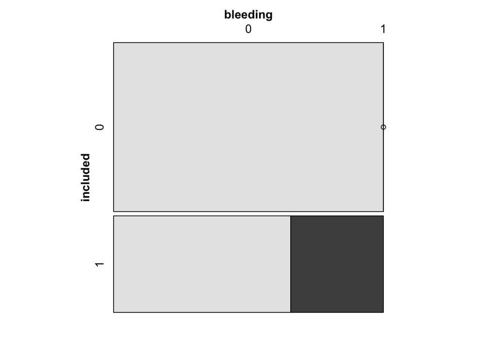

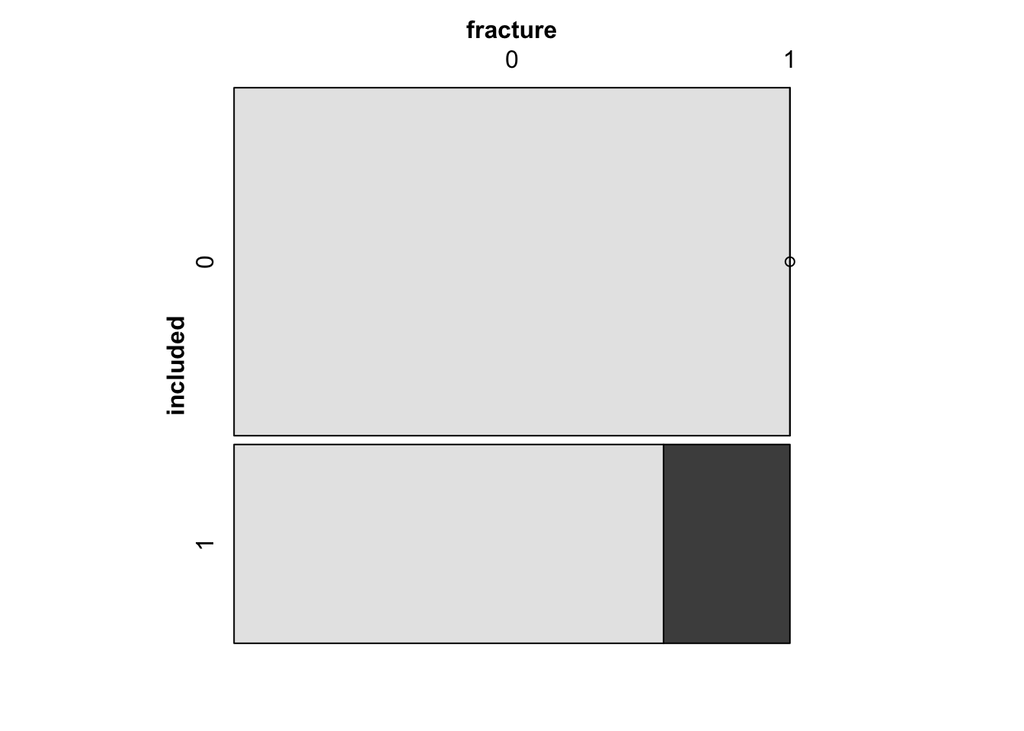

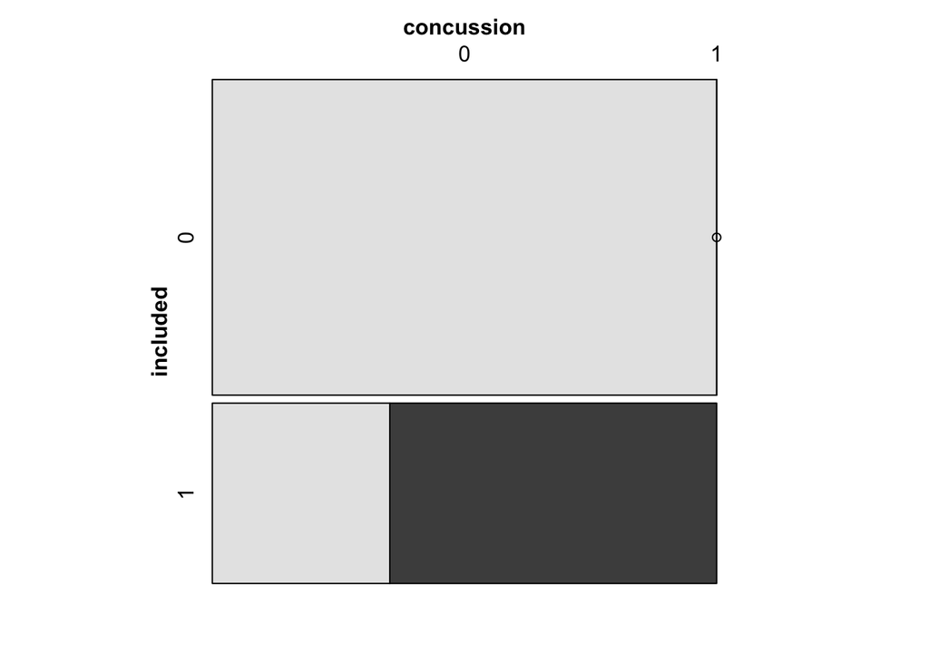

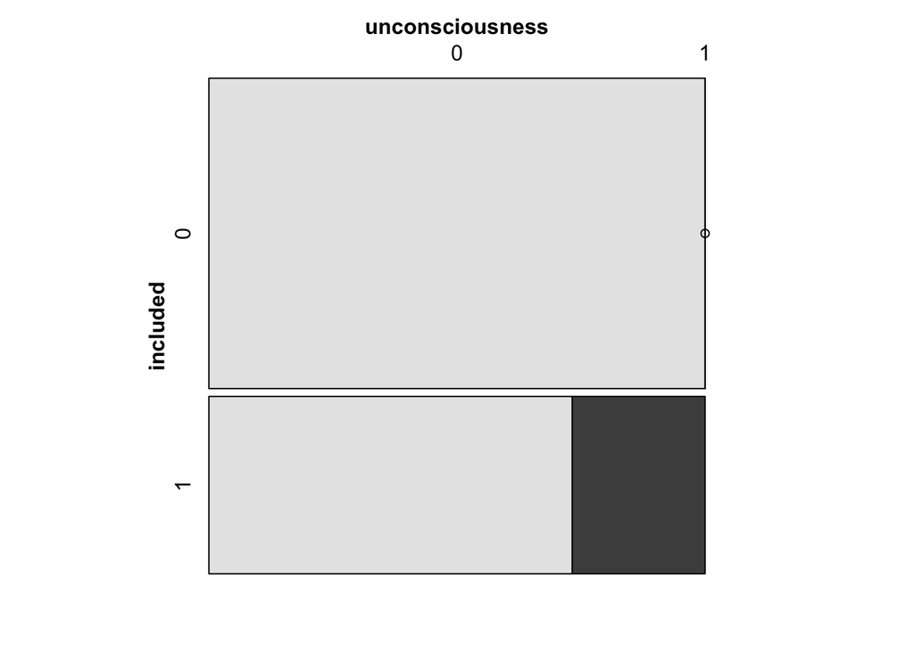

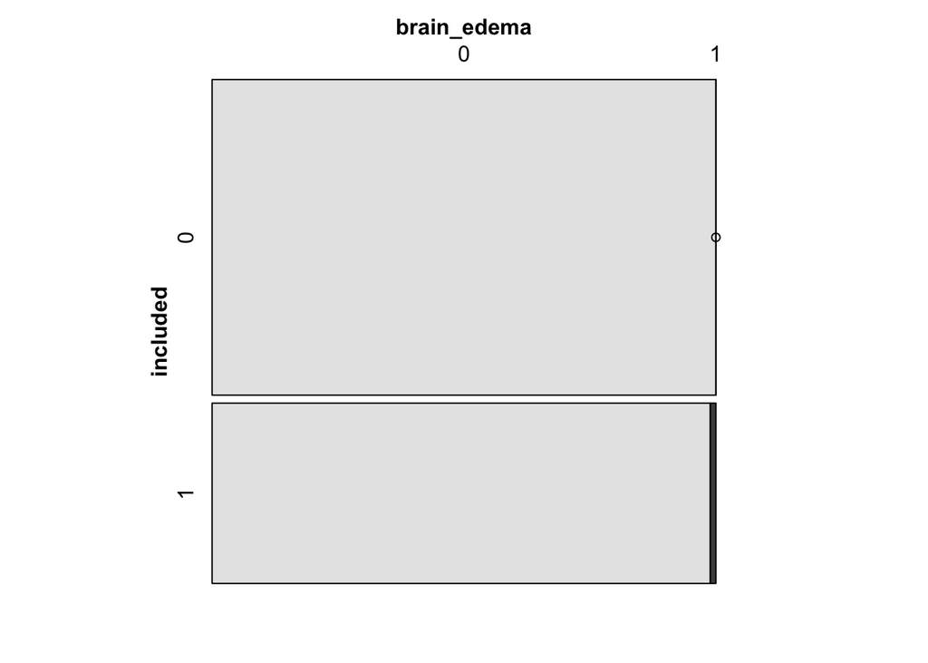

```r
# same for fractures and bleeding.

# check the difference in distributions of concussion, bleeding, fracture
# between the included and the non-included patients
mosaic(bleeding ~ included, Diagnosis_cleaned)
mosaic(fracture ~ included, Diagnosis_cleaned)
mosaic(concussion ~ included, Diagnosis_cleaned)
mosaic(unconsciousness ~ included, Diagnosis_cleaned)
mosaic(brain_edema ~ included, Diagnosis_cleaned)
```

```r
# ok, inclusion seems to be related to the presence of relevant TBI diagnoses!
# let's check if this may have been the inclusion criterion
included_cases2 <- Diagnosis_cleaned[bleeding + fracture + concussion +
                                       brain_edema + brain_compression +
                                       unconsciousness > 0]
# look at the missing ones
included_fail <- setdiff(Diagnosis_cleaned[included == 1],
                         included_cases2)
included_fail[, .(research_case_id,
                  injury_descriptions)]
```

```
##                        research_case_id
##                                  <char>
## 1: 6019349D-56BE-4165-B438-F76D0508734D
## 2: C8EA8685-59C7-42BA-91AB-16A9A1B8E3A7
## 3: EECEB3EC-5DFF-4C4F-B0D7-3714F28268A1
##                                                                                                                                                                                                                                                                                                  injury_d…
##                                                                                                                                                                                                                                                                                                          …
## 1: hämorrhagische diathese durch antikoagulanzien, primäre thrombophilie, krankheiten der mitral- und trikuspidalklappe, kombiniert, hypertensive herzkrankheit ohne (kongestive) herzinsuffizienz: ohne angabe einer hypertensiven krise, osteoporose, nicht näher bezeichnet: nicht näher bezeichnete l…
## 2:                                                                                                                pleuraerguss bei anderenorts klassifizierten krankheiten, sonstige komplikationen durch prothesen, implantate oder transplantate im urogenitaltrakt, sonstiger und nicht näher bezeichn…
## 3:                                                                                                                                                                                                                                       nichtbefolgung ärztlicher anordnungen [non-compliance] in der ei…
```

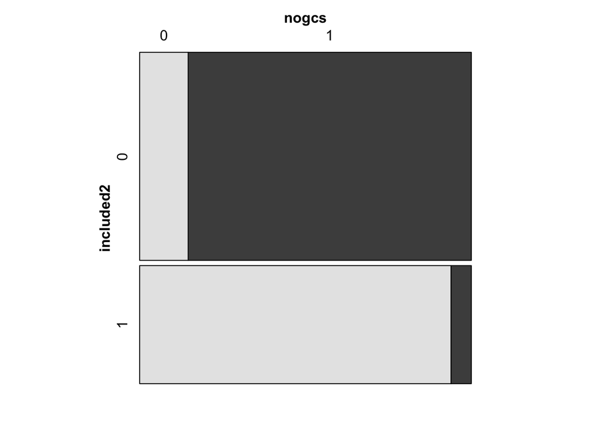

```r
# these do not even have a trauma-related diagosis?!

# ok, let's check the presence of gcs and our inclusion criterion
all_cases[, included2 := as.integer(research_case_id %in%
                                      included_cases2$research_case_id)]
mosaic(nogcs ~ included2, data = all_cases)
```

```r
# ok, most cases in the dataset with TBI actually has a GCS record!
```

OK, the mystery may be solved: The “included” cases seem to be those with at least one ICD-10 code corresponding to some form of traumatic brain injury! These cases are pretty much exactly the cases with a recorded GCS.

Still, I am wondering why there are records of cases with diagnoses that do not correspond to polytrauma. Maybe, the AIS values can help us here. We may define polytrauma as AIS scores of at least 3 in at least two different body regions (which corresponds to part of the Berlin definition).

```r
load(paste0(clean_path, "iss_clean.RData"))
Diagnosis_cleaned <- merge(x = Diagnosis_cleaned,
                           y = iss_clean,
                           by = "research_case_id",
                           all.x = TRUE)
# get AIS values to identify polytrauma
ais_mapping <- import_dataset(paste0(import_path,
                                     "[SDS].[v_Export_Mapping_Diagnosen_ICD_to_AIS_tra_sds].csv"))
polytrauma_ais <- ais_mapping[MAX_AIS_SEVERITY >= 3
                              ][, .(n_regions = n_distinct(AIS_CHAPTER)),
                                by = .(research_case_id)
                                ][n_regions >= 2]
nrow(polytrauma_ais)
```

```
## [1] 568
```

```r
# ok, only a fraction of these patients qualifies as having polytrauma in the
# strict sense! maybe the majority simply has injuries in at least two AIS
# body regions?

# let's check the distribution of body regions
ais_regions <- ais_mapping[, .(n_regions = n_distinct(AIS_CHAPTER)),
                           by = .(research_case_id)]
table(ais_regions$n_regions)
```

```
##
##    1    2    3    4    5    6    7    8    9
## 9218 4035 2054 1068  511  226   79   22    1
```

```r
# most cases only had one affected body region, these should not qualify as
# polytrauma! let's check if a dataset including cases with at least two
# injured regions is reasonable:
polytrauma_ais2 <- ais_mapping[, .(n_regions = n_distinct(AIS_CHAPTER)),
                               by = .(research_case_id)
                               ][n_regions >= 2]
# this look good. check how many of them are in the included data set.
length(intersect(polytrauma_ais2$research_case_id,
                 included_cases$research_case_id))
```

```
## [1] 5260
```

```r
# what about cases with TBI, but no polytrauma?
length(setdiff(included_cases$research_case_id,
               polytrauma_ais2$research_case_id))
```

```
## [1] 1896
```

```r
# oh ok, these are quite a few, too!
```

Okay, summarized:

- Not all patients in the dataset have polytrauma: Only 7996 out of 19699 according to a very broad definition.
- Not all patients with polytrauma have TBI: Only 5243 out of 7996.
- Conversely, out of 7132 patients with TBI, 5243 had polytrauma.
- GCS is missing in 2095 of 7996 polytrauma cases and in 436 of 7132 TBI cases.
- Generally, AIS is missing in 2485 of 19699 cases.

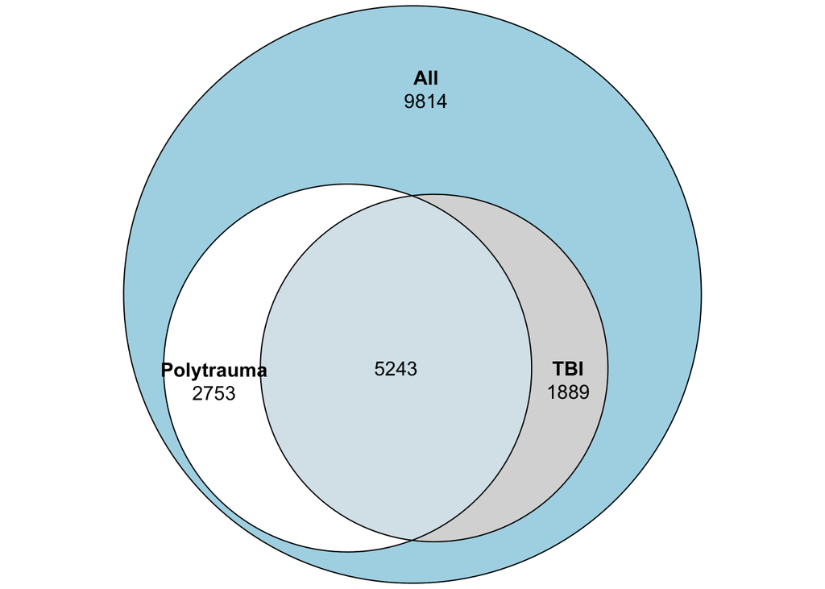

```r
# make data set with inclusion criteria for the different populations
all_cases[, polytrauma := as.integer(research_case_id %in%
                                       polytrauma_ais2$research_case_id)]
venndata <- all_cases[, .(polytrauma,
                          included2)]
venndata[, All := 1]
setnames(venndata,
         old = c("polytrauma", "included2"),
         new = c("Polytrauma", "TBI"))
vennfit <- euler(venndata)
plot(vennfit, quantities = TRUE)
```

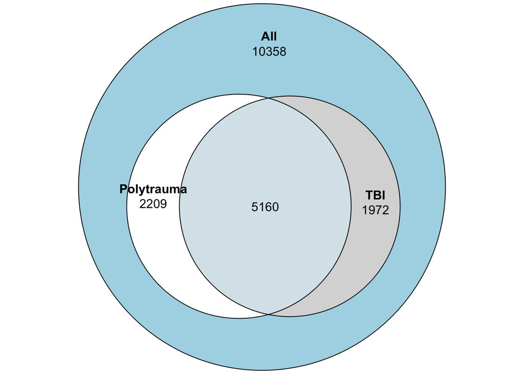

```r
# this definition of polytrauma may be too broad though due to the chapters
# that include general injuries and due to the scores of zero. make a more
# restrictive definition: AIS >= 1 in at least two AIS chapters except -1 and 0.
polytrauma_ais3 <- ais_mapping[AIS_CHAPTER > 0 & MAX_AIS_SEVERITY > 0
                               ][, .(n_regions = n_distinct(AIS_CHAPTER)),
                                 by = .(research_case_id)
                                 ][n_regions > 1]
all_cases[, polytrauma_restr := as.integer(research_case_id %in%
                                             polytrauma_ais3$research_case_id)]
venndata2 <- all_cases[, .(polytrauma_restr,
                           included2)]
venndata2[, All := 1]
setnames(venndata2,
         old = c("polytrauma_restr", "included2"),
         new = c("Polytrauma", "TBI"))
vennfit2 <- euler(venndata2)
plot(vennfit2, quantities = TRUE)
```

## AIS Values

```r
load(paste0(clean_path, "mapping_cleaned.RData"))
# calculate region AIS of each patient as maximum AIS value for that region
ais <- mapping_cleaned[, .(ais = max(MAX_AIS_SEVERITY)),
                       by = .(research_case_id,
                              AIS_CHAPTER)]
# check distribution of AIS values
xtabs(~ AIS_CHAPTER + ais, data = ais)
```

```
##            ais
## AIS_CHAPTER    0    1    2    3    4    5    6
##          -1 2462    0    0    0    0    0    0
##          0     1   94    0   28    0    0    0
##          1    18 3739 1399 2541    0    0    0
##          2     0 1640 1269    0    0    0    0
##          3    14  134   26   22    1    0    0
##          4     9  832 1045  821   15    2    0
##          5    21  675  402  111    4    5    0
##          6     0  174 2069   76    0  110    0
##          7    34 1483 4295    5   11    0    0
##          8    30 1441 3532 1555   12    0    0
##          9     0   47    9   35    9   20    1
```

```r
# there are only very few cases with more severe injuries!
# what about the cases with AIS scores of zero?
zeroais <- ais[ais == 0]
zeroais <- merge(zeroais,
                 Diagnosis_cleaned[, .(research_case_id,
                                       injury_descriptions)],
                 by = "research_case_id",
                 all.x = TRUE)
# check the body regions with zero values
table(zeroais$AIS_CHAPTER, useNA = "always")
```

```
##
##   -1    0    1    3    4    5    7    8 <NA>
## 2462    1   18   14    9   21   34   30    0
```

```r
# some of these are indeed actual body regions. let's check what they could mean
zeroais <- zeroais[AIS_CHAPTER != -1]
# mmhm, let's check the raw data
ais_mapping <- import_list(paste0(import_path,
                                  "[SDS].[v_Export_Mapping_Diagnosen_ICD_to_AIS_tra_sds].csv"),
                           rbind = TRUE,
                           setclass = "data.table")
zeroais <- ais_mapping[MAX_AIS_SEVERITY == 0 & AIS_CHAPTER != -1]
head(zeroais[, .(DESCRIPTION)], 10)
```

```
##                                                                                              DESCRIPTION
##                                                                                                   <char>
##  1:                                                               Traumatic rupture of ligament of wrist
##  2:                                                                     Other specified injuries of head
##  3:                                                              Unspecified injury of elbow and forearm
##  4: Injury of extensor muscle, fascia and tendon of other and unspecified finger at wrist and hand level
##  5:                                                                           Unspecified injury of head
##  6:                                                                      Unspecified injury of lower leg
##  7:                                                                           Unspecified injury of head
##  8: Injury of extensor muscle, fascia and tendon of other and unspecified finger at wrist and hand level
##  9:                                                              Injury of other blood vessels of thorax
## 10:                                                                      Injury of vein at forearm level
```

```r
# hm, this makes no sense...

# is this really a MAPPING between ICD-10 and AIS? let's check:
icd_mapping <- unique(ais_mapping[, .(Code,
                                      DESCRIPTION,
                                      MAX_AIS_SEVERITY)])
icd_mapping[, n := .N, by = .(Code)]
nrow(icd_mapping[n > 1])
```

```
## [1] 0
```

```r
# indeed: each ICD-10 code has exactly one AIS score!
```

It seems that the AIS scores were not assigned manually by the treating physicians, but that they were derived from ICD-10 codes assigned at hospital discharge. We need to clarify whether we want to use AIS scores belonging to the categories -1 (“No Map”) and 0 (“Other Trauma”) for a definition of polytrauma. Here are examples of these categories:

```r
rbind(unique(ais_mapping[AIS_CHAPTER == 0, .(AIS_CHAPTER, DESCRIPTION)]),
      unique(ais_mapping[AIS_CHAPTER == -1, .(AIS_CHAPTER, DESCRIPTION)])[1:15, ])
```

```
##     AIS_CHAPTER
##           <int>
##  1:           0
##  2:           0
##  3:           0
##  4:           0
##  5:          -1
##  6:          -1
##  7:          -1
##  8:          -1
##  9:          -1
## 10:          -1
## 11:          -1
## 12:          -1
## 13:          -1
```

[output cut: 27 more lines]

These are the distributions of score values in these categories.

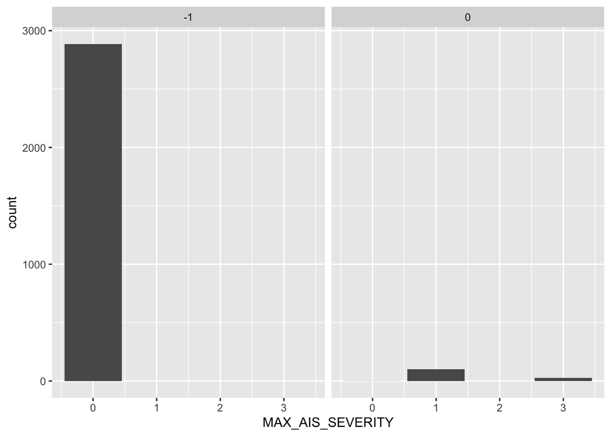

```r
ais_zeroone <- ais_mapping[AIS_CHAPTER <= 0]
ais_zeroone |>
  ggplot(aes(x = MAX_AIS_SEVERITY)) +
  geom_bar() +
  facet_wrap(~ AIS_CHAPTER)
```

That is:

- AIS chapter -1 (No Map) will most likely not contribute to the definition of polytrauma.
- AIS chapter 0 (Other Trauma) may contribute a few cases.